# README

Klaus Frieler

2025-01-15

## Simulation of measurement error correction procedures

To this end, we provide a R6 class, `ME_simulator`. To use this, first create an object of that class, with a bunch of parameters (whereall have reasonable defaults). For example, here is scenario 2 simulation

```r
mesim <- ME_simulator$new(scenario = 2,
                          n_batch = 1,
                          error_types = c("classical", "systematic", "heteroscedastic", "differential"),
                          measurement_errors = c(.05, 0.33, 0.67, 1, 1.52),
                          me_diffs = c(0),
                          n_sample = 50)
print(mesim)
```

```
## ME Simulator:
##   Coefficients:
##     b0 = 1.00
##     b1 = 0.40
##     b2 = 0.20
##
##   Metadata:
##     scenario: 2
##     N (sample): 50
##     N (batch): 1
##     Seed: --
##     Measurement Errors: 0.05, 0.33, 0.67, 1, 1.52
##     ME differences: 0
##     Error types: classical, systematic, heteroscedastic, differential
##     Corrections: no_correction, outlier_exclusion, LV, simex
##
##   State:
##     No. Results: 0
```

It set ups a simulation object with one batch (repetition of simulations) all four error types, five different measurement errors (expression as variance ratio) and no ME differences, which would simulate a mismatch of ME estimation, which enters the correction algorithms, and true ME, expressed as differences. For each simulated batch, we use a sample size of `n_sample = 50`.

After the object is created, we can run the simulations by using the object method `run.`

```r
mesim$run()
```

```
## Simulating data with 'classical' error (me_raw = 0.05)...
```

```
## ...  1 batches with me_diff = 0.00 -> me_total = 0.05.
```

```
## Simulating data with 'systematic' error (me_raw = 0.05)...
```

```
## ...  1 batches with me_diff = 0.00 -> me_total = 0.05.
```

```
## Simulating data with 'heteroscedastic' error (me_raw = 0.05)...
```

```
## ...  1 batches with me_diff = 0.00 -> me_total = 0.05.
```

```
## Simulating data with 'differential' error (me_raw = 0.05)...
```

```
## ...  1 batches with me_diff = 0.00 -> me_total = 0.05.
```

```
## Simulating data with 'classical' error (me_raw = 0.33)...
```

```
## ...  1 batches with me_diff = 0.00 -> me_total = 0.33.
```

```
## Simulating data with 'systematic' error (me_raw = 0.33)...
## ...  1 batches with me_diff = 0.00 -> me_total = 0.33.
```

```
## Simulating data with 'heteroscedastic' error (me_raw = 0.33)...
```

```
## ...  1 batches with me_diff = 0.00 -> me_total = 0.33.
```

```
## Simulating data with 'differential' error (me_raw = 0.33)...
```

```
## ...  1 batches with me_diff = 0.00 -> me_total = 0.33.
```

```
## Simulating data with 'classical' error (me_raw = 0.67)...
```

```
## ...  1 batches with me_diff = 0.00 -> me_total = 0.67.
```

```
## Simulating data with 'systematic' error (me_raw = 0.67)...
## ...  1 batches with me_diff = 0.00 -> me_total = 0.67.
```

```
## Simulating data with 'heteroscedastic' error (me_raw = 0.67)...
## ...  1 batches with me_diff = 0.00 -> me_total = 0.67.
```

```
## Simulating data with 'differential' error (me_raw = 0.67)...
## ...  1 batches with me_diff = 0.00 -> me_total = 0.67.
```

```
## Simulating data with 'classical' error (me_raw = 1.00)...
```

```
## ...  1 batches with me_diff = 0.00 -> me_total = 1.00.
```

```
## Simulating data with 'systematic' error (me_raw = 1.00)...
```

```
## ...  1 batches with me_diff = 0.00 -> me_total = 1.00.
```

```
## Simulating data with 'heteroscedastic' error (me_raw = 1.00)...
## ...  1 batches with me_diff = 0.00 -> me_total = 1.00.
```

```
## Simulating data with 'differential' error (me_raw = 1.00)...
## ...  1 batches with me_diff = 0.00 -> me_total = 1.00.
```

```
## Simulating data with 'classical' error (me_raw = 1.52)...
```

```
## ...  1 batches with me_diff = 0.00 -> me_total = 1.52.
```

```
## Simulating data with 'systematic' error (me_raw = 1.52)...
## ...  1 batches with me_diff = 0.00 -> me_total = 1.52.
```

```
## Simulating data with 'heteroscedastic' error (me_raw = 1.52)...
## ...  1 batches with me_diff = 0.00 -> me_total = 1.52.
```

```
## Simulating data with 'differential' error (me_raw = 1.52)...
## ...  1 batches with me_diff = 0.00 -> me_total = 1.52.
```

```
## # A tibble: 240 × 9
##    me_raw me_diff error_type method           name     error rel_error abs_error
##     <dbl>   <dbl> <chr>      <chr>            <chr>    <dbl>     <dbl>     <dbl>
##  1   0.05       0 classical  LV               b0     2.19e-4  0.000219  0.000219
##  2   0.05       0 classical  LV               b1    -1.26e-2 -0.0314    0.0126
##  3   0.05       0 classical  LV               b2    -1.11e-2 -0.0555    0.0111
##  4   0.05       0 classical  no_correction    b0     2.19e-4  0.000219  0.000219
##  5   0.05       0 classical  no_correction    b1    -1.35e-2 -0.0336    0.0135
##  6   0.05       0 classical  no_correction    b2    -1.13e-2 -0.0566    0.0113
##  7   0.05       0 classical  outlier_exclusi… b0     2.19e-4  0.000219  0.000219
##  8   0.05       0 classical  outlier_exclusi… b1    -1.35e-2 -0.0336    0.0135
##  9   0.05       0 classical  outlier_exclusi… b2    -1.13e-2 -0.0566    0.0113
## 10   0.05       0 classical  simex            b0     2.19e-4  0.000219  0.000219
## # ℹ 230 more rows
## # ℹ 1 more variable: rel_abs_error <dbl>
```

Per default, the verbosity is on, so we get a bunch of messages to watch the simulations going on. Note that this can take a long time, depending on the settings, With only single batch and one ME difference, this example will take a reasonable short time to run.

After the rum, the results are stored in the `mesim` object, and can be accessed directly, as well as some summary stats of the simulations.

```r
mesim$results
```

```
## # A tibble: 240 × 16
##    name  true_coefs coefs      se     error rel_error abs_error rel_abs_error
##    <chr>      <dbl> <dbl>   <dbl>     <dbl>     <dbl>     <dbl>         <dbl>
##  1 b0           1   1.00  0.00774  0.000219  0.000219  0.000219      0.000219
##  2 b1           0.4 0.387 0.00807 -0.0135   -0.0336    0.0135        0.0336
##  3 b2           0.2 0.189 0.00809 -0.0113   -0.0566    0.0113        0.0566
##  4 b0           1   1.00  0.00774  0.000219  0.000219  0.000219      0.000219
##  5 b1           0.4 0.387 0.00807 -0.0135   -0.0336    0.0135        0.0336
##  6 b2           0.2 0.189 0.00809 -0.0113   -0.0566    0.0113        0.0566
##  7 b0           1   1.00  0.00746  0.000219  0.000219  0.000219      0.000219
##  8 b1           0.4 0.387 0.00790 -0.0126   -0.0314    0.0126        0.0314
##  9 b2           0.2 0.189 0.00851 -0.0111   -0.0555    0.0111        0.0555
## 10 b0           1   1.00  0.00774  0.000219  0.000219  0.000219      0.000219
## # ℹ 230 more rows
## # ℹ 8 more variables: method <chr>, batch <int>, error_type <chr>,
## #   measurement_error <dbl>, measurement_error_diff <dbl>, n_sample <dbl>,
## #   n_batch <dbl>, measurement_error_raw <dbl>
```

```r
mesim$result_stats
```

```
## # A tibble: 240 × 9
##    me_raw me_diff error_type method           name     error rel_error abs_error
##     <dbl>   <dbl> <chr>      <chr>            <chr>    <dbl>     <dbl>     <dbl>
##  1   0.05       0 classical  LV               b0     2.19e-4  0.000219  0.000219
##  2   0.05       0 classical  LV               b1    -1.26e-2 -0.0314    0.0126
##  3   0.05       0 classical  LV               b2    -1.11e-2 -0.0555    0.0111
##  4   0.05       0 classical  no_correction    b0     2.19e-4  0.000219  0.000219
##  5   0.05       0 classical  no_correction    b1    -1.35e-2 -0.0336    0.0135
##  6   0.05       0 classical  no_correction    b2    -1.13e-2 -0.0566    0.0113
##  7   0.05       0 classical  outlier_exclusi… b0     2.19e-4  0.000219  0.000219
##  8   0.05       0 classical  outlier_exclusi… b1    -1.35e-2 -0.0336    0.0135
##  9   0.05       0 classical  outlier_exclusi… b2    -1.13e-2 -0.0566    0.0113
## 10   0.05       0 classical  simex            b0     2.19e-4  0.000219  0.000219
## # ℹ 230 more rows
## # ℹ 1 more variable: rel_abs_error <dbl>
```

There is also a flexible plotting option with the `diagnostics` memmber function. This will plot a metric (of your chosing) by correction method and error type over different ME, by default, but can be very flexibly configured.

```r
stats <- mesim$diagnostics(alpha = .7)
```

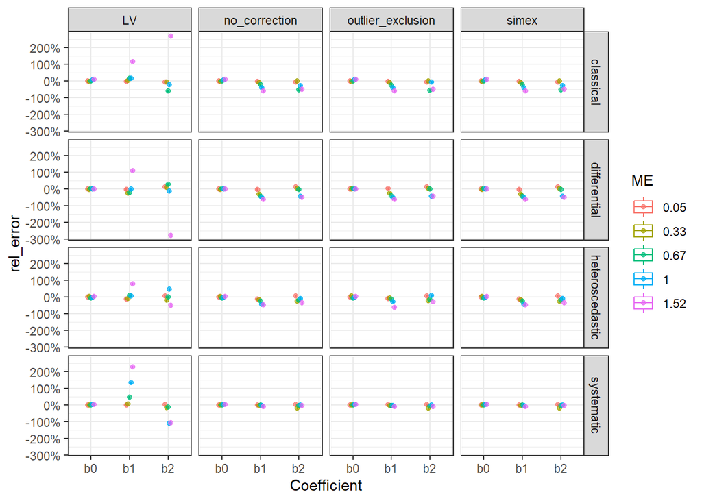

The object can also be conveniently be saved.

```r
mesim$save("my_sim.rds")
```

Have fun!